# Linear regression: wine analytics

Bikramjit Das

2025

# 1 Preliminaries

## 1.1 Attaching packages

```r
rm(list=ls())
#install.packages("ggplot2")
#install.packages("psych")
#install.packages("ggfortify")
library("ggplot2")
library("psych")
library("ggfortify")
```

## 1.2 Wine dataset

The data set consists of 38 observations of 6 variables (a small data set): 1952 to 1989. Orley Ashenfelter published his paper in 1990.

```r
wine <- read.csv("wine.csv")
str(wine)
```

```
## 'data.frame':    38 obs. of  6 variables:
##  $ VINT   : int  1952 1953 1954 1955 1956 1957 1958 1959 1960 1961 ...
##  $ LPRICE : num  -0.999 -0.454 NA -0.808 NA ...
##  $ WRAIN  : int  600 690 430 502 440 420 582 485 763 830 ...
##  $ DEGREES: num  17.1 16.7 15.4 17.1 15.7 ...
##  $ HRAIN  : int  160 80 180 130 140 110 187 187 290 38 ...
##  $ TIME_SV: int  31 30 29 28 27 26 25 24 23 22 ...
```

```r
summary(wine)
```

```
##       VINT          LPRICE           WRAIN          DEGREES
##  Min.   :1952   Min.   :-2.289   Min.   :376.0   Min.   :14.98
##  1st Qu.:1961   1st Qu.:-1.985   1st Qu.:510.2   1st Qu.:16.18
##  Median :1970   Median :-1.509   Median :586.5   Median :16.54
##  Mean   :1970   Mean   :-1.452   Mean   :605.0   Mean   :16.57
##  3rd Qu.:1980   3rd Qu.:-1.052   3rd Qu.:713.5   3rd Qu.:17.09
##  Max.   :1989   Max.   : 0.000   Max.   :845.0   Max.   :18.50
##                 NA's   :11
##      HRAIN          TIME_SV
##  Min.   : 38.0   Min.   :-6.00
##  1st Qu.: 87.5   1st Qu.: 3.25
##  Median :120.5   Median :12.50
##  Mean   :137.0   Mean   :12.50
##  3rd Qu.:171.0   3rd Qu.:21.75
##  Max.   :292.0   Max.   :31.00
##
```

## 1.3 Missing data

1954 and 1956 wine prices are not available in the dataset since they are rarely sold now. The prices from 1981 to 1989 are not available in the dataset.

```r
is.na(wine)
```

```
##        VINT LPRICE WRAIN DEGREES HRAIN TIME_SV
##  [1,] FALSE  FALSE FALSE   FALSE FALSE   FALSE
##  [2,] FALSE  FALSE FALSE   FALSE FALSE   FALSE
##  [3,] FALSE   TRUE FALSE   FALSE FALSE   FALSE
##  [4,] FALSE  FALSE FALSE   FALSE FALSE   FALSE
##  [5,] FALSE   TRUE FALSE   FALSE FALSE   FALSE
##  [6,] FALSE  FALSE FALSE   FALSE FALSE   FALSE
##  [7,] FALSE  FALSE FALSE   FALSE FALSE   FALSE
##  [8,] FALSE  FALSE FALSE   FALSE FALSE   FALSE
##  [9,] FALSE  FALSE FALSE   FALSE FALSE   FALSE
## [10,] FALSE  FALSE FALSE   FALSE FALSE   FALSE
## [11,] FALSE  FALSE FALSE   FALSE FALSE   FALSE
## [12,] FALSE  FALSE FALSE   FALSE FALSE   FALSE
## [13,] FALSE  FALSE FALSE   FALSE FALSE   FALSE
## [14,] FALSE  FALSE FALSE   FALSE FALSE   FALSE
```

[output cut: 24 more lines]

# 2 Visualization

## 2.1 Scatter plot: vintage vs. log-price

The scatter plot indicates a negative relationship but there is considerable variation that still needs to be captured. We can also plot a matrix of all pairwise scatter plots.

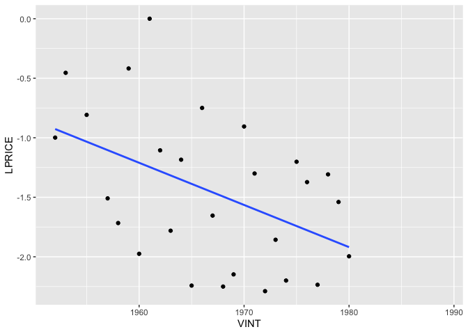

```r
ggplot(wine, aes(VINT,LPRICE)) + geom_point(na.rm=T)+geom_smooth(method="lm",na.rm=T,se=F)
```

## 2.2 Scatter plot of all pairs

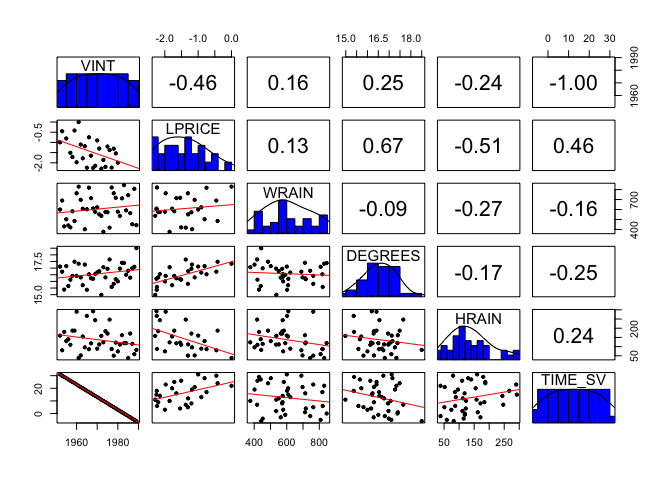

```r
pairs.panels(wine,ellipses = F, lm =T, breaks=10, hist.col="blue")  ## uses the psych package
```

```r
## ggpairs(wine) #uses the GGally package
## pairs(wine)
```

# 3 Fitting a model

## 3.1 Splitting the data

Split the data set into a training dataset from 1952 to 1978 (drop 1954 and 1956 since prices are not observable) and we use the test set from 1979 onwards. Note that for the test set however we only have prices till 1980 (so in this case we can only use 1979 and 1980) to test the model.

```r
winetrain <- subset(wine,wine$VINT<=1978 & !is.na(wine$LPRICE))
winetrain
```

```
##    VINT   LPRICE WRAIN DEGREES HRAIN TIME_SV
## 1  1952 -0.99868   600 17.1167   160      31
## 2  1953 -0.45440   690 16.7333    80      30
## 4  1955 -0.80796   502 17.1500   130      28
## 6  1957 -1.50926   420 16.1333   110      26
## 7  1958 -1.71655   582 16.4167   187      25
## 8  1959 -0.41800   485 17.4833   187      24
## 9  1960 -1.97491   763 16.4167   290      23
## 10 1961  0.00000   830 17.3333    38      22
## 11 1962 -1.10572   697 16.3000    52      21
## 12 1963 -1.78098   608 15.7167   155      20
## 13 1964 -1.18435   402 17.2667    96      19
## 14 1965 -2.24194   602 15.3667   267      18
## 15 1966 -0.74943   819 16.5333    86      17
## 16 1967 -1.65388   714 16.2333   118      16
## 17 1968 -2.25018   610 16.2000   292      15
## 18 1969 -2.14784   575 16.5500   244      14
## 19 1970 -0.90544   622 16.6667    89      13
## 20 1971 -1.30031   551 16.7667   112      12
## 21 1972 -2.28879   536 14.9833   158      11
## 22 1973 -1.85700   376 17.0667   123      10
## 23 1974 -2.19958   574 16.3000   184       9
## 24 1975 -1.20168   572 16.9500   171       8
## 25 1976 -1.37264   418 17.6500   247       7
## 26 1977 -2.23503   821 15.5833    87       6
## 27 1978 -1.30769   763 15.8167    51       5
```

```r
winetest <- subset(wine,wine$VINT>1978)
winetest
```

```
##    VINT   LPRICE WRAIN DEGREES HRAIN TIME_SV
## 28 1979 -1.53960   717 16.1667   122       4
## 29 1980 -1.99582   578 16.0000    74       3
## 30 1981       NA   535 16.9667   111       2
## 31 1982       NA   712 17.4000   162       1
## 32 1983       NA   845 17.3833   119       0
## 33 1984       NA   591 16.5000   119      -1
## 34 1985       NA   744 16.8000    38      -2
## 35 1986       NA   563 16.2833   171      -3
## 36 1987       NA   452 16.9833   115      -4
## 37 1988       NA   808 17.1000    59      -5
## 38 1989       NA   443 18.5000    82      -6
```

## 3.2 Single variable regression

One variable regression - `lm()` is the basic command to fit a linear model to the data.

### 3.2.1 Model 1: log-price vs. vintage

```r
?lm
model1  <- lm(LPRICE~VINT,data=winetrain)
model1
```

```
##
## Call:
## lm(formula = LPRICE ~ VINT, data = winetrain)
##
## Coefficients:
## (Intercept)         VINT
##    72.99301     -0.03786
```

```r
summary(model1)
```

```
##
## Call:
## lm(formula = LPRICE ~ VINT, data = winetrain)
##
## Residuals:
##      Min       1Q   Median       3Q      Max
## -0.84574 -0.46266 -0.09462  0.48752  1.24478
##
## Coefficients:
##             Estimate Std. Error t value Pr(>|t|)
## (Intercept) 72.99301   30.98789   2.356   0.0274 *
## VINT        -0.03786    0.01576  -2.402   0.0248 *
## ---
## Signif. codes:  0 '***' 0.001 '**' 0.01 '*' 0.05 '.' 0.1 ' ' 1
##
## Residual standard error: 0.594 on 23 degrees of freedom
## Multiple R-squared:  0.2005, Adjusted R-squared:  0.1657
## F-statistic: 5.768 on 1 and 23 DF,  p-value: 0.0248
```

```r
#autoplot(...) # uses the ggfortify package
```

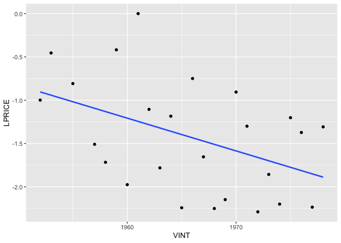

```r
ggplot(winetrain, aes(VINT,LPRICE))+geom_point(na.rm=T)+ geom_smooth(method="lm",na.rm = T,se=F)
```

Evaluate the sum of squared errors and total sum of squares.

```r
model1$residuals
```

```
##           1           2           4           6           7           8
## -0.09461844  0.48751867  0.20967287 -0.41591292 -0.58534581  0.75106129
##           9          10          11          12          13          14
## -0.76799160  1.24477550  0.17691260 -0.46049029  0.17399681 -0.84573608
##          15          16          17          18          19          20
##  0.68463102 -0.18196187 -0.74040477 -0.60020767  0.68004944  0.32303654
##          21          22          23          24          25          26
## -0.62758635 -0.15793925 -0.46266215  0.57309496  0.43999206 -0.38454083
##          27
##  0.58065627
```

```r
sse1 <- sum(model1$residuals^2)
sst1 <- sum((winetrain$LPRICE-mean(winetrain$LPRICE))^2)
R2<-1 - sse1/sst1  ### we did a direct computation but our model also gives an answer
R2
```

```
## [1] 0.2004897
```

The result indicates that older the wine, greater is the value but there is still significant variation.

### 3.2.2 Model 2: log-price vs. winter rain

```r
model2  <- lm(LPRICE~WRAIN,data=winetrain)
summary(model2)
```

```
##
## Call:
## lm(formula = LPRICE ~ WRAIN, data = winetrain)
##
## Residuals:
##      Min       1Q   Median       3Q      Max
## -0.95348 -0.65439  0.04172  0.43136  1.27550
##
## Coefficients:
##               Estimate Std. Error t value Pr(>|t|)
## (Intercept) -1.8331730  0.6286160  -2.916  0.00777 **
## WRAIN        0.0006719  0.0010155   0.662  0.51479
## ---
## Signif. codes:  0 '***' 0.001 '**' 0.01 '*' 0.05 '.' 0.1 ' ' 1
##
## Residual standard error: 0.6581 on 23 degrees of freedom
## Multiple R-squared:  0.01868,    Adjusted R-squared:  -0.02399
## F-statistic: 0.4377 on 1 and 23 DF,  p-value: 0.5148
```

### 3.2.3 Model 3: log-price vs. harvest rain

```r
model3  <- lm(LPRICE~HRAIN,data=winetrain)
summary(model3)
```

```
##
## Call:
## lm(formula = LPRICE ~ HRAIN, data = winetrain)
##
## Residuals:
##     Min      1Q  Median      3Q     Max
## -1.1116 -0.3228 -0.1008  0.3691  1.1977
##
## Coefficients:
##              Estimate Std. Error t value Pr(>|t|)
## (Intercept) -0.695162   0.249152   -2.79  0.01040 *
## HRAIN       -0.004923   0.001506   -3.27  0.00337 **
## ---
## Signif. codes:  0 '***' 0.001 '**' 0.01 '*' 0.05 '.' 0.1 ' ' 1
##
## Residual standard error: 0.5489 on 23 degrees of freedom
## Multiple R-squared:  0.3173, Adjusted R-squared:  0.2877
## F-statistic: 10.69 on 1 and 23 DF,  p-value: 0.003366
```

### 3.2.4 Model 4: log-price vs. temperature

```r
model4  <- lm(LPRICE~DEGREES,data=winetrain)
summary(model4)
```

```
##
## Call:
## lm(formula = LPRICE ~ DEGREES, data = winetrain)
##
## Residuals:
##      Min       1Q   Median       3Q      Max
## -0.78449 -0.23885 -0.03727  0.38994  0.90320
##
## Coefficients:
##             Estimate Std. Error t value Pr(>|t|)
## (Intercept) -11.9114     2.4935  -4.777 8.12e-05 ***
## DEGREES       0.6351     0.1509   4.208 0.000335 ***
## ---
## Signif. codes:  0 '***' 0.001 '**' 0.01 '*' 0.05 '.' 0.1 ' ' 1
##
## Residual standard error: 0.4993 on 23 degrees of freedom
## Multiple R-squared:  0.435,  Adjusted R-squared:  0.4105
## F-statistic: 17.71 on 1 and 23 DF,  p-value: 0.0003351
```

In conclusion, it seems a one-explanatory-variable regression model is not sufficient to explain the price of wine.

## 3.3 Two variable regression

The two variables selected are temperature (DEGREES) and harvest rain (HRAIN) and we want to find their effect on log-price (LPRICE).

### 3.3.1 Visualisation

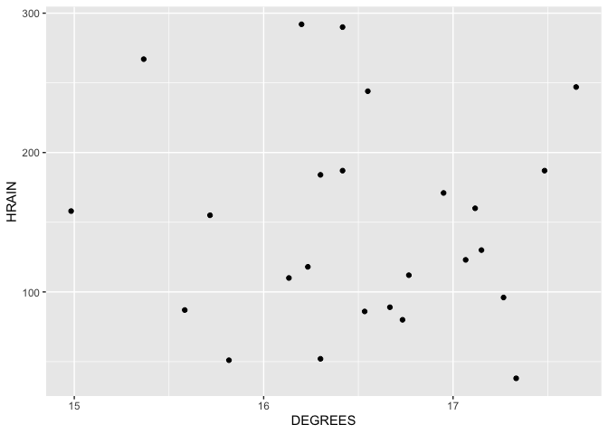

```r
ggplot(winetrain,aes(DEGREES,HRAIN))+geom_point()
```

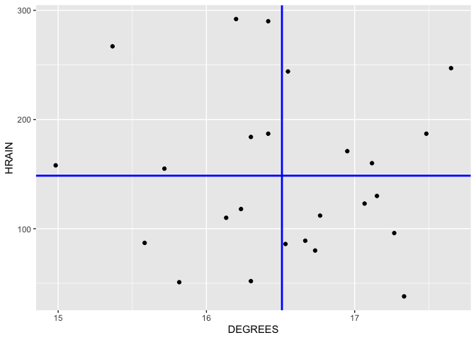

```r
ggplot(winetrain,aes(DEGREES,HRAIN))+geom_point()+geom_vline(xintercept=mean(winetrain$DEGREES),color="blue",lwd=1) + geom_hline(yintercept=mean(winetrain$HRAIN),color="blue",lwd=1)
```

```r
br<-mean(winetrain$LPRICE)
br
```

```
## [1] -1.42649
```

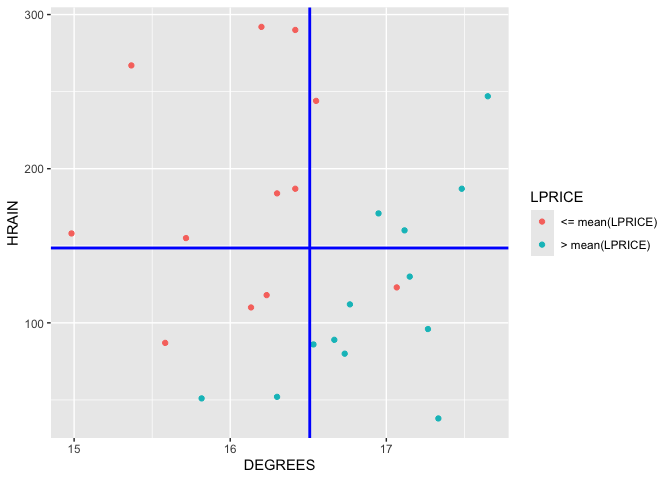

```r
ggplot(winetrain,aes(DEGREES,HRAIN,color=cut(LPRICE,c(-Inf,-1.42,Inf))))+geom_point(na.rm=T) + scale_color_discrete(name = "LPRICE", labels = c("<= mean(LPRICE)", "> mean(LPRICE)"))+geom_vline(xintercept=mean(winetrain$DEGREES),color="blue",lwd=1) + geom_hline(yintercept=mean(winetrain$HRAIN),color="blue",lwd=1)
```

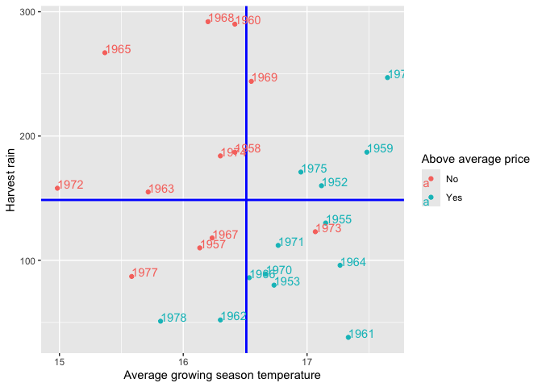

```r
ggplot(winetrain,aes(DEGREES,HRAIN,color=cut(LPRICE,c(-Inf,-1.42,Inf)),label=VINT))+geom_point(na.rm=T) + scale_color_discrete(name = "Above average price", labels = c("No", "Yes"))+geom_vline(xintercept=mean(winetrain$DEGREES),color="blue",lwd=1) + geom_hline(yintercept=mean(winetrain$HRAIN),color="blue",lwd=1) + geom_text(aes(label=VINT),hjust=0, vjust=0) + xlab("Average growing season temperature") + ylab("Harvest rain")
```

```r
#ggplot(winetrain,aes(DEGREES,HRAIN,color=LPRICE,label=VINT))+geom_point(na.rm=T)+geom_vline(xintercept=mean(winetrain$DEGREES),color="blue",lwd=1) + geom_hline(yintercept=mean(winetrain$HRAIN),color="blue",lwd=1) + geom_text(aes(label=VINT),hjust=0, vjust=0) + xlab("Average growing season temperature") + ylab("Harvest rain")


#ggsave("HrainTemp.png", width = 10, height = 7)
```

The figure indicates that hot and dry summers produce wines that obtain higher prices while cooler summers with more rain gives lower priced wines. 1961 is an year where an extremely high quality wine was produced.

### 3.3.2 Model 5: two variable regression

```r
model5  <- lm(LPRICE~HRAIN+DEGREES,data=winetrain)
summary(model5)
```

```
##
## Call:
## lm(formula = LPRICE ~ HRAIN + DEGREES, data = winetrain)
##
## Residuals:
##      Min       1Q   Median       3Q      Max
## -0.88319 -0.19599  0.06181  0.15379  0.59724
##
## Coefficients:
##              Estimate Std. Error t value Pr(>|t|)
## (Intercept) -10.69628    1.85444  -5.768 8.40e-06 ***
## HRAIN        -0.00457    0.00101  -4.525 0.000167 ***
## DEGREES       0.60261    0.11128   5.415 1.94e-05 ***
## ---
## Signif. codes:  0 '***' 0.001 '**' 0.01 '*' 0.05 '.' 0.1 ' ' 1
##
## Residual standard error: 0.3674 on 22 degrees of freedom
## Multiple R-squared:  0.7074, Adjusted R-squared:  0.6808
## F-statistic: 26.59 on 2 and 22 DF,  p-value: 1.348e-06
```

We obtain the following regression model:
$$LPRICE = -10.69 + 0.602*DEGREES -
0.0045*HRAIN.$$
Both variables are highly significant under this model with $R^2 = 0.7$ and adjusted-$R^2 = 0.68.$

## 3.4 Multiple linear regression

### 3.4.1 Model 6: log-price vs. all variables

```r
model6  <- lm(LPRICE~.,data=winetrain)
summary(model6)
```

```
##
## Call:
## lm(formula = LPRICE ~ ., data = winetrain)
##
## Residuals:
##      Min       1Q   Median       3Q      Max
## -0.45473 -0.24276  0.00753  0.19770  0.53640
##
## Coefficients: (1 not defined because of singularities)
##               Estimate Std. Error t value Pr(>|t|)
## (Intercept) 35.5297567 16.4435924   2.161 0.043028 *
## VINT        -0.0239302  0.0080969  -2.955 0.007821 **
## WRAIN        0.0010756  0.0005073   2.120 0.046684 *
## DEGREES      0.6072099  0.0987030   6.152  5.2e-06 ***
## HRAIN       -0.0039715  0.0008538  -4.652 0.000154 ***
## TIME_SV             NA         NA      NA       NA
## ---
## Signif. codes:  0 '***' 0.001 '**' 0.01 '*' 0.05 '.' 0.1 ' ' 1
##
## Residual standard error: 0.295 on 20 degrees of freedom
## Multiple R-squared:  0.8286, Adjusted R-squared:  0.7943
## F-statistic: 24.17 on 4 and 20 DF,  p-value: 2.036e-07
```

```r
cor(winetrain)
```

```
##                VINT     LPRICE       WRAIN     DEGREES       HRAIN     TIME_SV
## VINT     1.00000000 -0.4477608  0.01697002 -0.24691585  0.02800907 -1.00000000
## LPRICE  -0.44776081  1.0000000  0.13666199  0.65955892 -0.56332212  0.44776081
## WRAIN    0.01697002  0.1366620  1.00000000 -0.32109061 -0.27544085 -0.01697002
## DEGREES -0.24691585  0.6595589 -0.32109061  1.00000000 -0.06449593  0.24691585
## HRAIN    0.02800907 -0.5633221 -0.27544085 -0.06449593  1.00000000 -0.02800907
## TIME_SV -1.00000000  0.4477608 -0.01697002  0.24691585 -0.02800907  1.00000000
```

Note that TIME_SV coefficient is not available in the model as it is perfectly correlated with the VINT variable (perfect multi-collinearity). We drop the variable and redo the regression. High correlation (in absolute value) between independent variables is not good (indication of multi-collinearity) while high correlation (in absolute value) between dependent and independent variables is good

### 3.4.2 Model 7: log-price vs. all (relevant) variables

```r
model7  <- lm(LPRICE~VINT+HRAIN+WRAIN+DEGREES,data=winetrain)
summary(model7)
```

```
##
## Call:
## lm(formula = LPRICE ~ VINT + HRAIN + WRAIN + DEGREES, data = winetrain)
##
## Residuals:
##      Min       1Q   Median       3Q      Max
## -0.45473 -0.24276  0.00753  0.19770  0.53640
##
## Coefficients:
##               Estimate Std. Error t value Pr(>|t|)
## (Intercept) 35.5297567 16.4435924   2.161 0.043028 *
## VINT        -0.0239302  0.0080969  -2.955 0.007821 **
## HRAIN       -0.0039715  0.0008538  -4.652 0.000154 ***
## WRAIN        0.0010756  0.0005073   2.120 0.046684 *
## DEGREES      0.6072099  0.0987030   6.152  5.2e-06 ***
## ---
## Signif. codes:  0 '***' 0.001 '**' 0.01 '*' 0.05 '.' 0.1 ' ' 1
##
## Residual standard error: 0.295 on 20 degrees of freedom
## Multiple R-squared:  0.8286, Adjusted R-squared:  0.7943
## F-statistic: 24.17 on 4 and 20 DF,  p-value: 2.036e-07
```

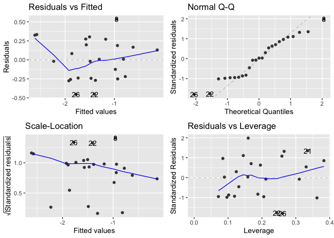

```r
autoplot(model7) ## ggfortify
```

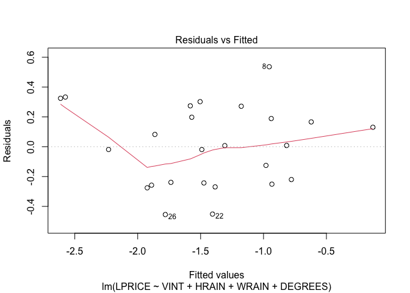

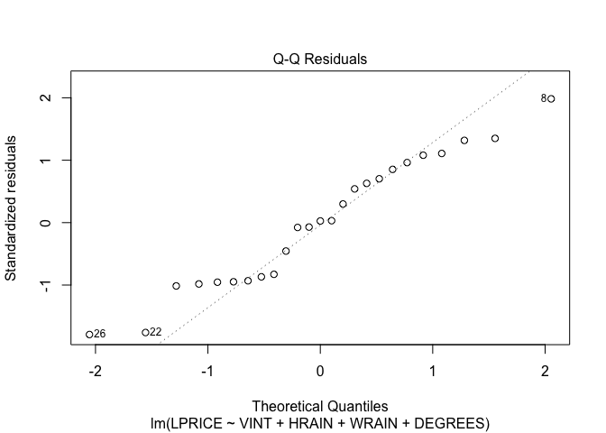

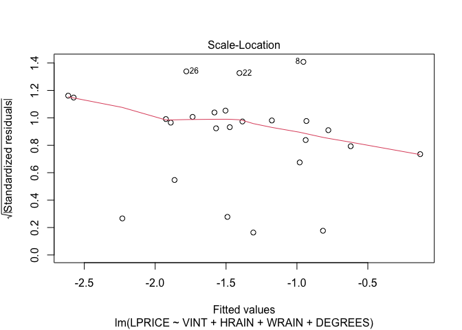

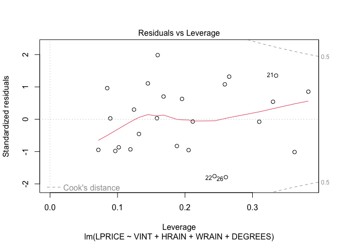

```r
plot(model7)
```

Under this model we have $R^2 = 0.828$ and adjusted-$R^2 = 0.794$. The coefficients indicate that high quality wines correlate strongly in a positive manner with summer temperatures, negatively correlate with harvest rain and positively correlate with winter rain. The result indicates that 80% of the variation can be explained by including the weather variables in comparison to 20% with only the vintage year.

### 3.4.3 Model 7alt: log-price vs. winter rain, harvest rain and temperature

```r
model7alt <- lm(LPRICE~WRAIN+DEGREES+HRAIN,data=winetrain)
summary(model7alt)
```

```
##
## Call:
## lm(formula = LPRICE ~ WRAIN + DEGREES + HRAIN, data = winetrain)
##
## Residuals:
##      Min       1Q   Median       3Q      Max
## -0.67475 -0.12957  0.01975  0.20754  0.63848
##
## Coefficients:
##               Estimate Std. Error t value Pr(>|t|)
## (Intercept) -1.280e+01  2.037e+00  -6.282 3.13e-06 ***
## WRAIN        1.177e-03  5.920e-04   1.987 0.060085 .
## DEGREES      6.810e-01  1.117e-01   6.097 4.75e-06 ***
## HRAIN       -3.948e-03  9.987e-04  -3.953 0.000726 ***
## ---
## Signif. codes:  0 '***' 0.001 '**' 0.01 '*' 0.05 '.' 0.1 ' ' 1
##
## Residual standard error: 0.345 on 21 degrees of freedom
## Multiple R-squared:  0.7537, Adjusted R-squared:  0.7185
## F-statistic: 21.42 on 3 and 21 DF,  p-value: 1.359e-06
```

We also obtain estimated coefficients for a linear regression model after dropping VINT but this decreases $R^2$ to 0.75 and adjusted $R^2$ to 0.71.

## 3.5 Confidence intervals

We can obtain confidence intervals for the estimates using the `confint` command.

```r
model4$coefficients
```

```
## (Intercept)     DEGREES
## -11.9113839   0.6350888
```

```r
#model4$residuals
confint(model4)
```

```
##                  2.5 %     97.5 %
## (Intercept) -17.069618 -6.7531495
## DEGREES       0.322896  0.9472816
```

```r
confint(model4,level=0.99) ## End of class Sep 30
```

```
##                   0.5 %    99.5 %
## (Intercept) -18.9115253 -4.911243
## DEGREES       0.2114179  1.058760
```

# 4 Predictions

The `predict` function helps predict the outcome of the model on values in the test set.

```r
str(winetest)
```

```
## 'data.frame':    11 obs. of  6 variables:
##  $ VINT   : int  1979 1980 1981 1982 1983 1984 1985 1986 1987 1988 ...
##  $ LPRICE : num  -1.54 -2 NA NA NA ...
##  $ WRAIN  : int  717 578 535 712 845 591 744 563 452 808 ...
##  $ DEGREES: num  16.2 16 17 17.4 17.4 ...
##  $ HRAIN  : int  122 74 111 162 119 119 38 171 115 59 ...
##  $ TIME_SV: int  4 3 2 1 0 -1 -2 -3 -4 -5 ...
```

```r
wineprediction7 <- predict(model7, newdata=winetest)
wineprediction7
```

```
##         28         29         30         31         32         33         34
## -1.7247744 -1.8087984 -1.4389334 -1.2119306 -0.9321766 -1.7656490 -1.1211635
##         35         36         37         38
## -2.1817252 -1.6775926 -1.0253562 -0.6831185
```

```r
cbind(c(1979,1980),wine$LPRICE[28:29],wineprediction7[1:2])
```

```
##    [,1]     [,2]      [,3]
## 28 1979 -1.53960 -1.724774
## 29 1980 -1.99582 -1.808798
```

```r
exp(cbind(wine$LPRICE[28:29],wineprediction7[1:2]))
```

```
##         [,1]      [,2]
## 28 0.2144669 0.1782132
## 29 0.1359022 0.1638509
```

The $R^2$ values obtained from the training data are as follows:

1. Model 4: $R^2=0.435$;
2. Model 5: $R^2=0.707$;
3. Model 7: $R^2=0.828$.

Now we find this for the test data set.

```r
sst <-sum((winetest$LPRICE[1:2]-mean(winetrain$LPRICE))^2) ## winetrain instead of winetest in this case due to small test set

sse7 <- sum((wineprediction7[1:2]-winetest$LPRICE[1:2])^2)

R2_7<- 1-sse7/sst
R2_7
```

```
## [1] 0.7944189
```

```r
wineprediction4 <- predict(model4,newdata=winetest) ## prediction with Model 4
sse4 <- sum((wineprediction4[1:2]-winetest$LPRICE[1:2])^2)
R2_4<- 1-sse4/sst
R2_4
```

```
## [1] 0.7881924
```

```r
wineprediction5 <- predict(model5,newdata=winetest) ## prediction with Model 5
sse5 <- sum((wineprediction5[1:2]-winetest$LPRICE[1:2])^2)
R2_5<-1-sse5/sst
R2_5
```

```
## [1] -0.08201462
```

We use the training mean to compute the total sum of squares for computing the test $R^2$ values (since the test set has so few values, if you have more values in the test set, no need to resort to this). The results indicate that better $R^2$ in the training set does not necessarily indicate better $R^2$ in test set (this can also be negative as seen in `Model 5`).

The use of logarithms for prices is fairly common in the economics literature - partly justified by skewed values in some datasets dealing with numbers such as salaries and partly justified by functional relations such as $y = \exp(a+bx)$ which gives $\log y = a+bx.$ Such transformations need to be justified and is sometime specific to domains. Even if one directly uses prices in the regression, similar insights are found in this dataset.

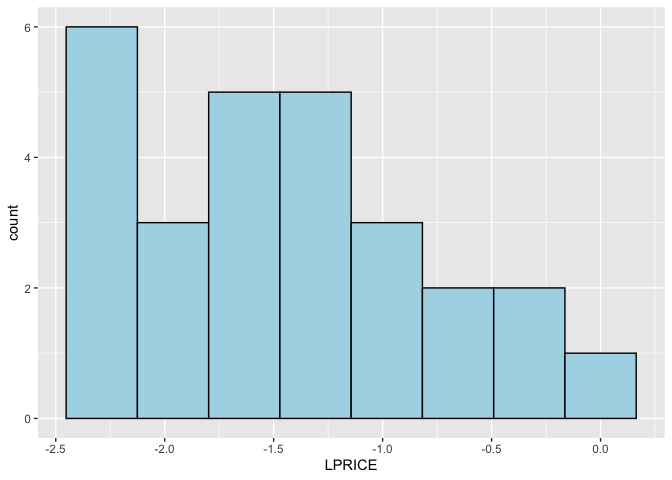

```r
library(ggplot2)

ggplot(wine,aes(LPRICE))+geom_histogram(bins=8,na.rm=T,color="black",fill="lightblue")
```

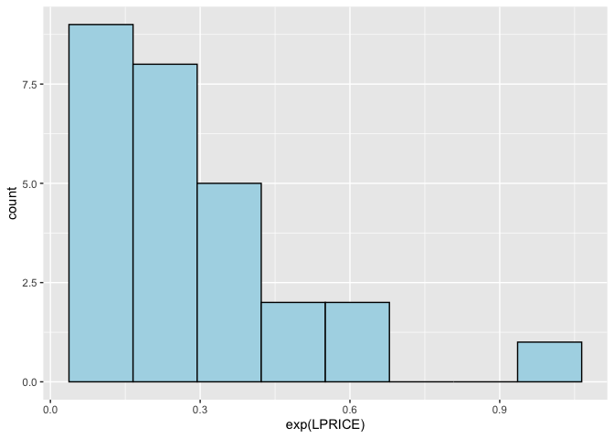

```r
ggplot(wine,aes(exp(LPRICE)))+geom_histogram(bins=8,na.rm=T,color="black",fill="lightblue")
```

```r
#hist(wine$LPRICE)
#hist(exp(wine$LPRICE))
```